# Chapter 1: Introduction

Machine Learning

Author

F.San Segundo & N.Rodríguez

Published

January 2026

# Course Description and Grading

**Course description:**

The objective of this introductory course to Machine Learning is to provide students with a fundamental understanding and an extensive practical experience of how to *extract knowledge from data*.

**Course goals:**

- Understand the basic principles behind Machine Learning.
- Gain practical experience with the most relevant Machine Learning algorithms.
- Have well-formed criteria to choose the most appropriate technique for a given application.

**Grading:**

**This is a summary**, see the [Course Guide for the official version](https://repositorio.comillas.edu/xmlui/bitstream/handle/11531/102745/GD%20DTC-MIINT-517%20Python%20Programming%20Fundamentals%202025-2026.pdf?sequence=1).

- 15% Mid-term exam
- 35% Final exam ($\geq 4$)
- 50% Lab
- Retake

**Schedule.**

Abridged version: due dates for tests and assignments to be confirmed.

*January to February, before the Midterm (scheduled for the first week of March):*

- Ch. 1: Introduction
- Ch. 2: Supervised Learning: Classification $\rightarrow$ Assignment 1
- Ch. 3: Supervised Learning: Regression

*Late February to late March:*

- Ch. 4: Supervised Learning: Forecasting $\rightarrow$ Assignment 2

*April (Easter in the first week, last lecture day April 22th)*

- Ch. 5: Unsupervised Learning

*Final Exam (late April or early May)*

*Final Exam Retake (June)*

# Introduction to Machine Learning

**Motivation for ML**

- We are in a data rich but information poor situation.
- In general, decision makers do not have the tools to extract the valuable knowledge embedded in the vast amounts of data.
- Data-driven decisions increasingly make the difference between keeping up with competitors or falling further behind.

[figure not shown]

- [Harvard Business Review Article 1](https://hbr.org/2012/10/data-scientist-the-sexiest-job-of-the-21st-century)
- [Harvard Business Review Article 2](https://hbr.org/2017/05/8-ways-machine-learning-is-improving-companies-work-processes)

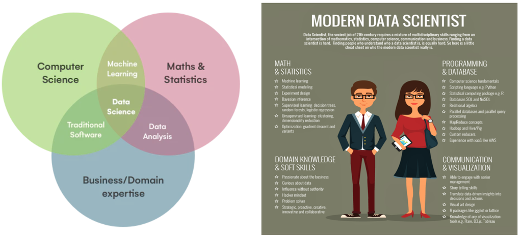

**Temptative Definitions of Machine Learning**

- Field of study that gives computers the ability to learn without being explicitly programmed.
- Making computers to modify or adapt their actions so that these actions get more accurate.
- A machine is said to learn if it is able to take experience and utilize it such that its performance improves up on similar experiences in the future.
- [Ted Talk by Jeremy Howard: The wonderful and terrifying implications of computers that can learn.](https://www.ted.com/talks/jeremy_howard_the_wonderful_and_terrifying_implications_of_computers_that_can_learn)

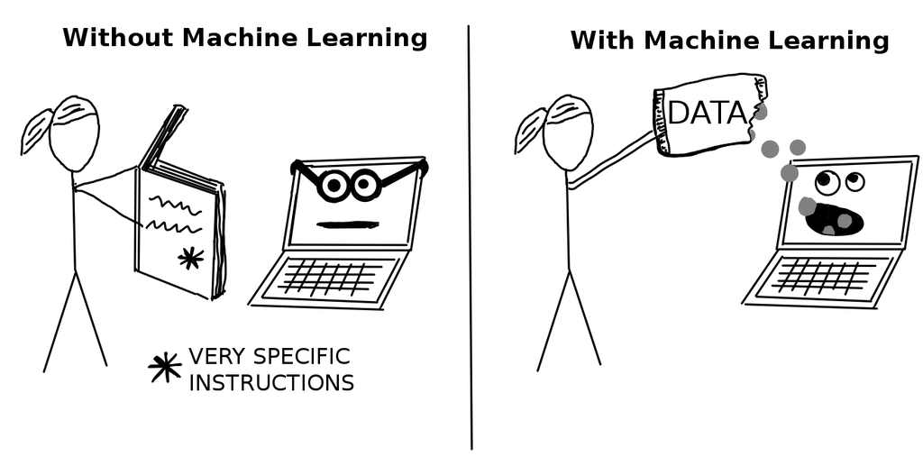

**Machine Learning Timeline**

[Source: Machine Learning Timeline (from DEEP LEARNING EXPLAINED by NVIDIA)](https://www.nvidia.com/content/dam/en-zz/Solutions/deep-learning/home/DeepLearning_eBook_FINAL.pdf)

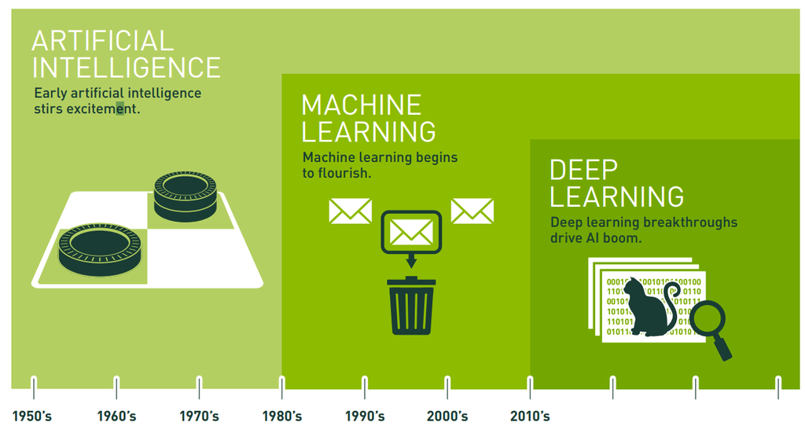

**The Learning Process**

[Source: https://imarticus.org/what-is-machine-learning-and-does-it-matter/](https://imarticus.org/what-is-machine-learning-and-does-it-matter/)

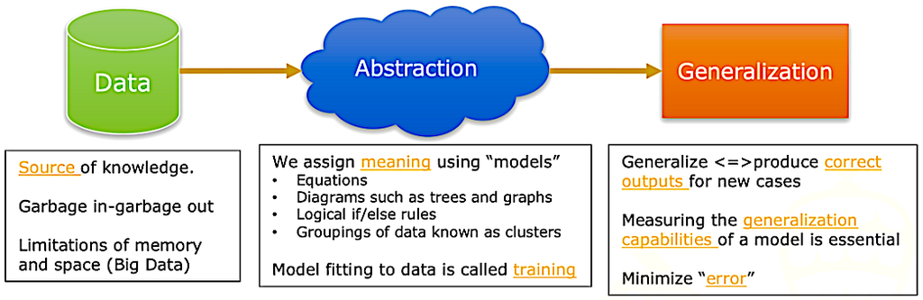

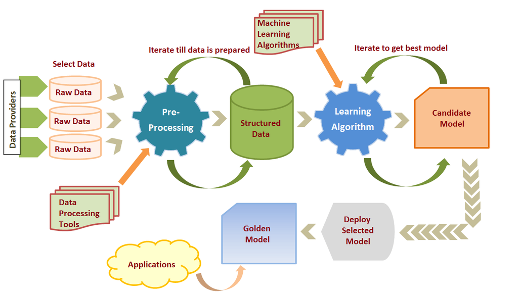

**Types of Learning**

The following diagram attempts to describe the major problem families addressed by Machine Learning. We will next briefly describe some of these families that we will meet in the course.

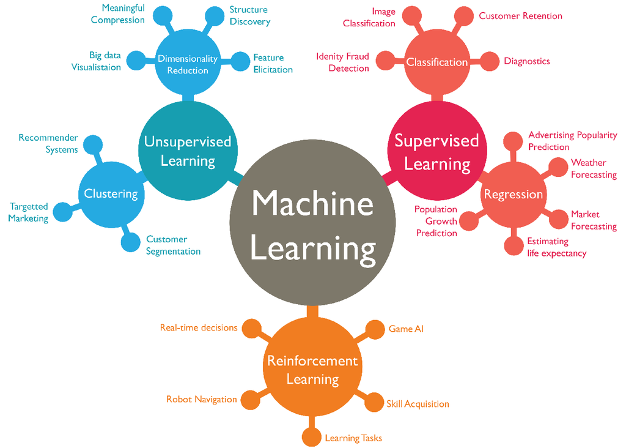

**Supervised Learning**

The aim of *Supervised Learning* is to learn an input-output mapping from a “labelled” dataset.
$$Y \sim f(X_1,\ldots, X_n)$$
where

- $Y$ is the *output* or *response* variable.
- $X_i$ are the *input* or *explanatory* variables.
- $f$ is a function that approximates output as a function of inputs.

**Applications:**

- Classification
- Regression
- Forecasting

**Supervised Learning: Classification**

In **classification** problems we have a **categorical output variable** $Y$. That is $Y$ is a **factor** that divides the data into **classes/levels**.

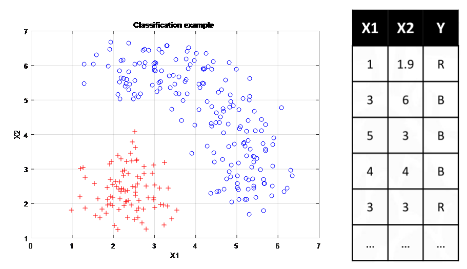

**Supervised Learning: Regression**

- In **regression** problems we have a **numerical output variable** $Y$.

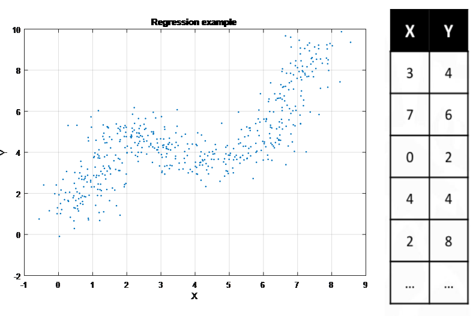

**Supervised Learning: Forecasting**

In **forecasting** problems we use **past values of the output variable** $Y$ to **predict its future values**.
$$\underbrace{Y_t}_{\text{Output at time }t} \sim \underbrace{f(Y_{t-1}, Y_{t-2},\,\ldots)}_{\text{Output at previous time values}}$$

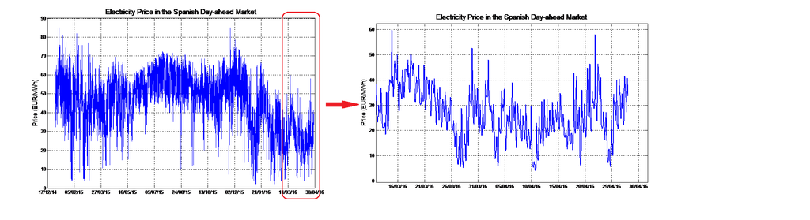

# Software setup

**Detailed Setup Guide**

Follow the `[instructions here.](https://ml-mic.github.io/MLMIIN_public/MLMIIN26_Student_Setup_Guide.html#typical-workflow-for-each-session)

**Note:** If you have started there, and you have completed the setup, then you can continue below. Just make sure that you use the *select kernel* button (top right corner of this window) to select the correct Python environment for this notebook, as described in the setup guide.

**Python Setup Checks**

To test that your python setup is looking good please execute the remaining Python cells in this document. Begin by checking the output of the following commands. It should be `/opt/conda/envs/mlmiin/bin/python`.

```python
import sys
print(sys.executable)
```

```
/opt/conda/envs/mlmiin/bin/python
```

**Check the Basic Libraries for Data Science with Python**

Check the versions and make sure that no errors appear in the output of the code cells below.

First check the Python version you are using (it should be 3.11.14).

```python
print("Python version:", sys.version)
```

```
Python version: 3.11.14 | packaged by conda-forge | (main, Oct 22 2025, 22:39:18) [GCC 14.3.0]
```

**Note about standard imports**

Many Python libraries have **standard import names**. These are not official names, but we will **require their use**, to make your code readable and compatible. For example, NumPy should **always** be imported as `np`.

**NumPy**

[NumPy Official Website and Documentation: https://numpy.org/](https://numpy.org/)

```python
# Standard import for NumPy
import numpy as np
np.__version__
```

```
'2.3.5'
```

A minimal performance check ([Read here about `%timeit` and other built-in magic commands to use in your notebooks](https://ipython.readthedocs.io/en/stable/interactive/magics.html))

```python
a = np.random.rand(1000)
%timeit a @ a
```

```
630 ns ± 19.1 ns per loop (mean ± std. dev. of 7 runs, 1,000,000 loops each)
```

**Pandas**

[Pandas Official Website and Documentation: https://pandas.pydata.org/](https://pandas.pydata.org/)

```python
# Standard import for Pandas
import pandas as pd
pd.__version__
```

```
'2.3.3'
```

**MatplotLib and Seaborn**

[MatplotLib Official Website and Documentation: https://matplotlib.org/](https://matplotlib.org/)  
[Seaborn Official Website and Documentation: https://seaborn.pydata.org/](https://seaborn.pydata.org/)

```python
# The Standard import for Matplotlib is
import matplotlib as mpl
# But we will more frequently use this import sequence
import matplotlib.pyplot as plt
mpl.__version__
```

```
'3.10.8'
```

```python
# Standard import for Seaborn
import seaborn as sns
sns.__version__
```

```
'0.13.2'
```

**Scikit**

[scikit-learn Official Website and Documentation: https://scikit-learn.org/](https://scikit-learn.org/)

```python
# Standard import for Scikit-learn
import sklearn as sk
sk. __version__
```

```
'1.7.2'
```

# Working with Pandas DataFrame Objects.

**The Titanic Dataset**

For our first example we will use a data set called `titanic`, available in the Seaborn library that you should have already installed. The data set contains information about the passengers of the Titanic, such as their age, gender, class in which they were traveling, whether they survived the ship shinking, etc. We will soon see how to use Python to read data from different sources: csv and Excel files, urls, databases, APIs, etc. But for now we just want to run some tests and get an overview of the data structures we will be working with.

```python
titanic = sns.load_dataset('titanic')
type(titanic)
```

```
pandas.core.frame.DataFrame
```

As you can see, `titanic` is now a **Pandas DataFrame**. This, alongside with **NumPy arrays**, is the type of data objects that we will most frequently meet when working with data.

**First Look at the Dataset**

To see the first lines of the `titanic` data set we can use the `head` method. The optional `n` argument determines the number of rows in the output (the default is `n = 5`).  
**Note:** you will notice sone `NaN` values in the `deck` column of the table. This are *missing data*. We will see how to deal with missing data through the course lectures.

```python
titanic.head(4)
```

|  | survived | pclass | sex | age | sibsp | parch | fare | embarked | class | who | adult_male | deck | embark_town | alive | alone |
| --- | --- | --- | --- | --- | --- | --- | --- | --- | --- | --- | --- | --- | --- | --- | --- |
| 0 | 0 | 3 | male | 22.0 | 1 | 0 | 7.2500 | S | Third | man | True | NaN | Southampton | no | False |
| 1 | 1 | 1 | female | 38.0 | 1 | 0 | 71.2833 | C | First | woman | False | C | Cherbourg | yes | False |
| 2 | 1 | 3 | female | 26.0 | 0 | 0 | 7.9250 | S | Third | woman | False | NaN | Southampton | yes | True |
| 3 | 1 | 1 | female | 35.0 | 1 | 0 | 53.1000 | S | First | woman | False | C | Southampton | yes | False |

**Exercise 001.**

Try running the above with other values of `n`. Also run it as `print(titanic.head(4))`. Use the *Help* menu to open the *Reference* link and look up the information about the `head` method for Pandas DataFrames.

**Basic properties of a DataFrame**

How many rows and columns of data are there in this data set? We get the answer with the `shape` method in Pandas:

```python
titanic.shape
```

```
(891, 15)
```

**Exercise 002.**

- What happens if you just use the name of the DataFrame in a notebook?
- Apply the Pandas methods `info` and `describe` to the Titanic Dataframe.
- Also run the command `titanic.size` and `len(titanic)`.
- Note that `size`, just as `shaoe`, is an attribute, not a method. Also note that `len` is a function. Make sure that you understand how these concepts are different from each other.

```python
len(titanic)
```

```
891
```

**Columns of the DataFrame**

To see the *column names* we use, quite naturally:

```python
titanic.columns
```

```
Index(['survived', 'pclass', 'sex', 'age', 'sibsp', 'parch', 'fare',
       'embarked', 'class', 'who', 'adult_male', 'deck', 'embark_town',
       'alive', 'alone'],
      dtype='object')
```

**Index of a DataFrame**

As we see, the column names are stored in an `Index` object. We will learn more about indices later in the course, but we can start with the idea that sometimes the rows of the Datafframe (or groups of rows) can contain information as well. This information is stored in the index which and be accessed as follows.

```python
titanic.index
```

```
RangeIndex(start=0, stop=891, step=1)
```

In this case the answer indicates that the index is just the sequence of row numbers.

**Accessing the data**

We can get any element in the data table using brackets, the `iloc` method and row/column number pairs.

For example, to get the element in the second row and fourth column we use:

```python
titanic.iloc[1, 3]
```

```
np.float64(38.0)
```

**Always keep in mind that Python counts are zero-based!!**

The zero index corresponds to the first element in an ordered set.

**Tidy Data**

In a tidy data table:

- the columns correspond to variables
- the rows correspond to observations.

*And we should have a very good reason to do otherwise!!* [Wikipedia page (Spanish version with links to English References)](https://es.wikipedia.org/wiki/Tidy_data)

In the above example, the fourth column corresponds to the `age` variable of the Titanic passengers. It is often better to refer to variables by their names. We can do it with the `loc` method:

```python
titanic.loc[1, 'age']
```

```
np.float64(38.0)
```

In this dataframe the row indices are numeric (in fact, consecutive zero-based integers), so we can use 1 with `loc` or `iloc` to select a row.

**Accessing complete columns**

Columns in a dataframe can be accesed with brackets and the quoted variable name, or with `loc`. But with `loc` we must use a colon `:` to include all the rows.

To extract the `age` column

```python
titanic['age'] # or also titanic.loc[:, "age"]
```

```
0      22.0
1      38.0
2      26.0
3      35.0
4      35.0
       ...
886    27.0
887    19.0
888     NaN
889    26.0
890    32.0
Name: age, Length: 891, dtype: float64
```

**Warning**

The `age` column can also be accessed as an attribute of the table, with `titanic.age`. **The bracket method is required if the variable name contains special characters**, but this *attribute notation* can be handy when we want to shorten our code sentences.

**Dataframe Columns and Pandas Series**

What kind of object is one such *extracted column*? It is not a *dataframe with a single column* (those exist too) but a *Pandas Series* object. In Pandas a DataFrame can be considered as a collection of Series (columns) with a common (row) index. Missing this tricky point leads to many mistakes.

```python
type(titanic['age'])
```

```
pandas.core.series.Series
```

We have just said that dataframes with a single column exist. In this case you can turn the resultin `Series` into one such dataframe as follows.

```python
age_df = pd.DataFrame(titanic['age'])
age_df.head(4)
```

|  | age |
| --- | --- |
| 0 | 22.0 |
| 1 | 38.0 |
| 2 | 26.0 |
| 3 | 35.0 |

**Modifying data**

The `loc` and `iloc` methods can also be used to modify elements of the table. Let us modify the age of that passenger and check the result with head:

```python
titanic.iloc[1, 3] = 19.0
titanic.head(4)
```

|  | survived | pclass | sex | age | sibsp | parch | fare | embarked | class | who | adult_male | deck | embark_town | alive | alone |
| --- | --- | --- | --- | --- | --- | --- | --- | --- | --- | --- | --- | --- | --- | --- | --- |
| 0 | 0 | 3 | male | 22.0 | 1 | 0 | 7.2500 | S | Third | man | True | NaN | Southampton | no | False |
| 1 | 1 | 1 | female | 19.0 | 1 | 0 | 71.2833 | C | First | woman | False | C | Cherbourg | yes | False |
| 2 | 1 | 3 | female | 26.0 | 0 | 0 | 7.9250 | S | Third | woman | False | NaN | Southampton | yes | True |
| 3 | 1 | 1 | female | 35.0 | 1 | 0 | 53.1000 | S | First | woman | False | C | Southampton | yes | False |

**Exercise 003.**

1. Now use `ioc` instead of `iloc` to return the age of the passenger to the original `38.0` value and check your work with `head`.
2. Run the comand `type(titanic[['age']])`. Note the difference with `type(titanic['age'])`.

**Accessing Larger Portions of the DataFrame Through Indexing**

If we want to access several rows and or columns we can use explicit *indexing* with lists (note that the order is relevant). The `loc` and `iloc` methods can also be used to modify elements of the table.

```python
titanic.loc[[0, 1, 2, 3, 4] , ['sex', 'age', 'survived', 'pclass']]
```

|  | sex | age | survived | pclass |
| --- | --- | --- | --- | --- |
| 0 | male | 22.0 | 0 | 3 |
| 1 | female | 19.0 | 1 | 1 |
| 2 | female | 26.0 | 1 | 3 |
| 3 | female | 35.0 | 1 | 1 |
| 4 | male | 35.0 | 0 | 3 |

**Slicing**

In *slicing* we use the colon `:` to get consecutive rows or columns.

```python
titanic.loc[:4 , 'survived':'age']
```

|  | survived | pclass | sex | age |
| --- | --- | --- | --- | --- |
| 0 | 0 | 3 | male | 22.0 |
| 1 | 1 | 1 | female | 19.0 |
| 2 | 1 | 3 | female | 26.0 |
| 3 | 1 | 1 | female | 35.0 |
| 4 | 0 | 3 | male | 35.0 |

**Warning**

- Contrary to the usual Python (and NumPy) convention, in Pandas **the final values of the indices are included in the output for `loc`.**
- You can also use slicing with `iloc`. However, in this case **the final values of the numeric indexes are excluded in the output for `iloc`**.

```python
titanic.iloc[:2 , 0:2]
```

|  | survived | pclass |
| --- | --- | --- |
| 0 | 0 | 3 |
| 1 | 1 | 1 |

**Condition based filtering**

One of the most powerful tools in data analysis is the ability to filter only those rows of a data table that meet some condition, usually expressed as a *boolean* condition. In Pandas we can use loc for this task.

For example, we can filter the `titanic` DataFrame, keeping only the rows corresponding to female passengers with ages equal or greater than 25 years.

```python
ttnc_female_25plus = titanic.loc[(titanic["age"] >= 25) &  (titanic["sex"] == "female")]
ttnc_female_25plus.iloc[:, 0:8].head(4)
```

|  | survived | pclass | sex | age | sibsp | parch | fare | embarked |
| --- | --- | --- | --- | --- | --- | --- | --- | --- |
| 2 | 1 | 3 | female | 26.0 | 0 | 0 | 7.9250 | S |
| 3 | 1 | 1 | female | 35.0 | 1 | 0 | 53.1000 | S |
| 8 | 1 | 3 | female | 27.0 | 0 | 2 | 11.1333 | S |
| 11 | 1 | 1 | female | 58.0 | 0 | 0 | 26.5500 | S |

**Controlling the Output**

Note that in the last line of the previous code chunk we have used `iloc` to select the columns that appear in the output. **Always be mindful of the output of your commands!** Communication skills are an essential tool in Data Science and Machine Learning!

**Grouping**

Together with conditional selection, grouping observations provides an essential tool to study the distribution of the variables in the dataset and answer questions about them.

```python
ttnc_female_25plus.groupby(by="class", observed=True )["fare"].mean()
```

```
class
First     104.930704
Second     20.199113
Third      16.705341
Name: fare, dtype: float64
```

**Plots**

We will have plenty of opportunities to learn how to use different types of plots to explore and visualize our data. BUt to begin with the subject and close this session we show below how to obtain a simple graph out of a pandas Dataframe.

In fact, let us plot a histogram of the `age` variable (using MatplotLib).

```
array([[<Axes: title={'center': 'age'}>]], dtype=object)
```

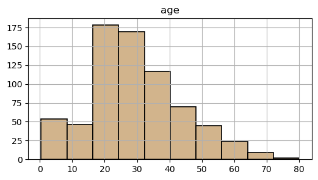

```python
titanic.hist('age', edgecolor='black', linewidth=1.2, color = "tan", figsize=(6, 3))
```

**Next Session**

In the next session we will start with the first family of supervised learning models: classification models. We will spend several sessions studying such models, using them to lay the foundations of Machine Learning in general, as well as the Python tools we will use throughout the course.